# Deforestation, Group 47

Low Eeron(A0216716E), Callista Stephine Yu (A0219743Y),Le Van Minh (A0219739N),Muhammad Imtiyaaz (A0216752E)

2023-04-14

## Introduction

The Deforestation data set (2021-04-06) provides a detailed look at global forest loss, its extent, and contributing factors. This resource allows readers to understand deforestation’s worldwide impact over the years and major contributing factors to the changes seen.The datasets used from this repo are forest_area.csv, and brazil_loss.csv.Using these data sets the two question we will be answering is 1.How has the top 5 countries with the largest forest area percentage in 1990 changed over the years? 2.What are the top 5 factors contributing to deforestation in Brazil for each year?

```r
forest_area <- readr::read_csv('https://raw.githubusercontent.com/rfordatascience/tidytuesday/master/data/2021/2021-04-06/forest_area.csv', show_col_types = FALSE)
brazil_loss <- readr::read_csv('https://raw.githubusercontent.com/rfordatascience/tidytuesday/master/data/2021/2021-04-06/brazil_loss.csv', show_col_types = FALSE)
library(tidyverse)
if (!requireNamespace("scales", quietly = TRUE)) {
  install.packages("scales")
}
library(scales)
```

```r
library(ggplot2)
```

## Descriptive statistics

`forest_area` contains column `entity`, which can be countries, continents, and other special economics regions. Only countries have non-missing `code`. The year in this dataset ranges from 1990-2020.

```r
# Representatives for countries, continents, subregions, and self-governing archipelagos
representatives <- c("China", "Africa", "Caribbean", "Faroe Islands")

forest_area %>%
  filter(entity %in% representatives & year == 2000)
```

```
## # A tibble: 4 × 4
##   entity        code   year forest_area
##   <chr>         <chr> <dbl>       <dbl>
## 1 Africa        <NA>   2000 17.1
## 2 Caribbean     <NA>   2000  0.164
## 3 China         CHN    2000  4.26
## 4 Faroe Islands <NA>   2000  0.00000192
```

In `brazil_loss`, there’re some suspicious zeros. These might be missing values, and the data collectors just put them as zeros for convenience. However, it can also be due to irregular economics activities (dams flooding, mining, etc.), so we decided not to impute these data points, but to leave them how we found them.

```r
brazil_loss %>%
  select(code, year, flooding_due_to_dams, mining) %>%
  head(10)
```

```
## # A tibble: 10 × 4
##    code   year flooding_due_to_dams mining
##    <chr> <dbl>                <dbl>  <dbl>
##  1 BRA    2001                    0   9000
##  2 BRA    2002                79000   9000
##  3 BRA    2003                    0      0
##  4 BRA    2004                26000      0
##  5 BRA    2005                17000      0
##  6 BRA    2006                17000      0
##  7 BRA    2007                 9000   9000
##  8 BRA    2008                    0   9000
##  9 BRA    2009                 9000      0
## 10 BRA    2010                    0   4000
```

```r
summary(forest_area)
```

```
##     entity              code                year       forest_area
##  Length:7846        Length:7846        Min.   :1990   Min.   :  0.00000
##  Class :character   Class :character   1st Qu.:1998   1st Qu.:  0.00174
##  Mode  :character   Mode  :character   Median :2005   Median :  0.06237
##                                        Mean   :2005   Mean   :  1.80865
##                                        3rd Qu.:2013   3rd Qu.:  0.44651
##                                        Max.   :2020   Max.   :100.00000
```

```r
unique(forest_area$year)
```

```
##  [1] 1990 1991 1992 1993 1994 1995 1996 1997 1998 1999 2000 2001 2002 2003 2004
## [16] 2005 2006 2007 2008 2009 2010 2011 2012 2013 2014 2015 2016 2017 2018 2019
## [31] 2020
```

## Question 1:How has the top 5 countries with the largest forest area percentage in 1990 changed over the years?

### Introduction

Deforestation is a big factor in climate change in our society. Therefore we analyze the top 5 countries with the largest forest area in 1990 using the forest_area dataset to study their changes in forest area percentages over time. This is important as it will showcase the changes to the forest area in these countries. This is vital as we can learn from the governmental policies and environmental regulations used in the countries that have positive forest area growth to replicate them in countries contributing to the deforestation problem.

### Visualizations

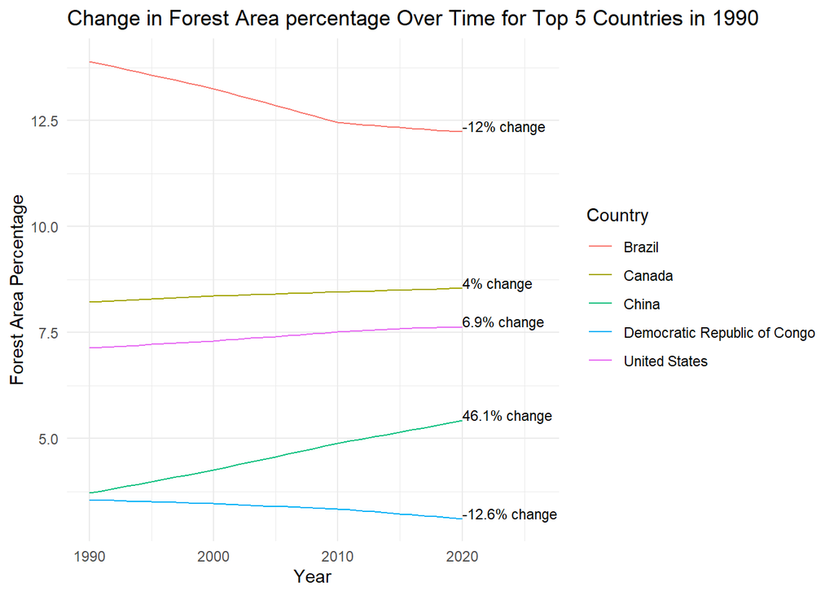

```r
options(warn = -1)
# Filter the data for the top 5 countries with the largest forest area percentage in 1990
top5_1990 <- forest_area %>%
  filter(year == 1990) %>%
  filter(!is.na(code)) %>%
  filter(entity != "World") %>%
  arrange(desc(forest_area)) %>%
  slice(c(1,2,3,4,5)) %>%
  pull(entity)

# Filter the forest_area dataset for the top 5 countries
forest_area_top5 <- forest_area %>%
  filter(entity %in% top5_1990)

# Calculate the percentage change in forest area for each country relative to its forest area percentage in 1990
forest_area_top5 <- forest_area_top5 %>%
  group_by(entity) %>%
  mutate(pct_change = (forest_area / forest_area[year == 1990] - 1) * 100)

# Create a line chart showing the change in forest area for the top 5 countries over time
ggplot_forest_area <- ggplot(forest_area_top5, aes(x = year, y = forest_area, color = entity)) +
  geom_line() +
  labs(title = "Change in Forest Area percentage Over Time for Top 5 Countries in 1990",
       x = "Year",
       y = "Forest Area Percentage",
       color = "Country") +
  scale_y_continuous(sec.axis = sec_axis(trans = "log",
                                         breaks = c(50, 100, 200, 500, 1000, 2000, 5000, 10000),
                                         labels = c(50, 100, 200, 500, 1000, 2000, 5000, 10000))) +
  geom_text(data = subset(forest_area_top5, year == 2020),
            aes(x = year, y = forest_area, label = paste0(round(pct_change, 1), "% change")),
            hjust = -0, vjust = 0, size = 3, color = "black")+
  theme_minimal() +
  scale_x_continuous(limits = c(min(forest_area_top5$year), 2026)) # Extend x-axis to 2025

ggplot_forest_area
```

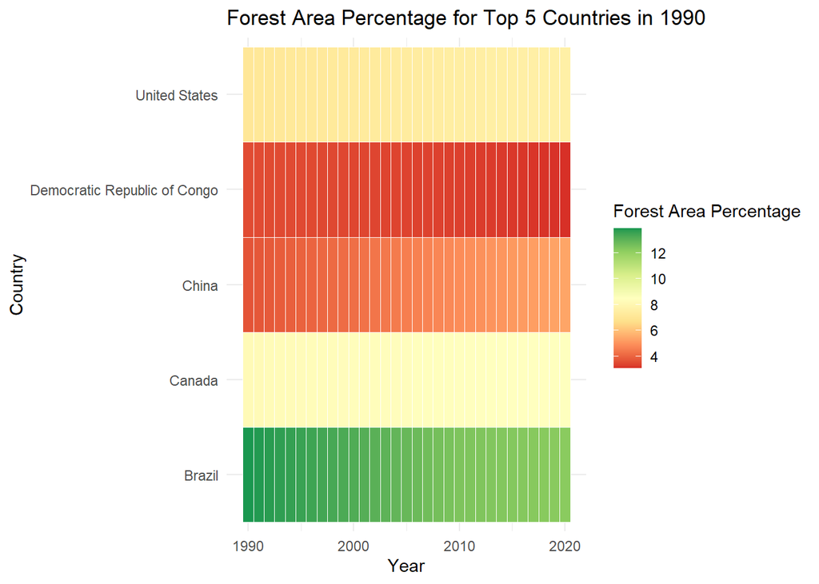

```r
# Create a heat map of the forest area percentage for the top 5 countries over time
ggplot_forest_area_heatmap <- ggplot(forest_area_top5, aes(x = year, y = entity, fill = forest_area)) +
  geom_tile(color = "white") +
  scale_fill_distiller(palette = "RdYlGn", direction = 1,  # Use RdYlGn palette and reverse direction
                       type = "seq", guide = guide_colorbar()) +
  labs(title = "Forest Area Percentage for Top 5 Countries in 1990",
       x = "Year",
       y = "Country",
       fill = "Forest Area Percentage") +
  theme_minimal()

# Print the plot
print(ggplot_forest_area_heatmap)
```

## Question 2:What are the top 5 factors contributing to deforestation in Brazil for each year?

### Introduction

In this analysis, we examine the top 5 drivers of deforestation in Brazil over time, utilizing a dataset containing information on area loss due to various factors. Brazil, with one of the world’s largest forest areas, is an important region to study for understanding the environmental impacts of deforestation. The goal is to uncover trends that can inform policy decisions and strategies for sustainable forest management. By focusing on Brazil and the main factors contributing to deforestation, we aim to shed light on the changes in these drivers over time. This exploration can ultimately contribute to preserving biodiversity and mitigating the effects of deforestation.

### Methodology

To answer the question about the top 5 deforestation drivers in Brazil over time, we created two distinct visualizations using the dataset containing information on area loss (in hectares) attributed to various factors.The first plot is a dodged bar chart displaying the area loss (in hectares) on a log10 scale on the y-axis and the years on the x-axis. This plot highlights the top 5 drivers of deforestation for each year, allowing us to easily compare their magnitudes. The drivers are represented by different colors, and the data is grouped and ranked by the total deforestation caused by each driver.The second visualization is a stacked area chart, showing the percentage of total deforestation caused by each driver over time. With years on the x-axis and the percentage of total deforestation on the y-axis, this plot provides an overview of the drivers’ relative contributions to deforestation. Each driver is represented by a distinct color, allowing us to observe how their respective shares have evolved over time.Both visualizations complement each other by providing different perspectives on the same question. While the dodged bar chart emphasizes the absolute area loss values caused by each driver, the stacked area chart focuses on their relative contributions. Together, these plots enable us to identify trends and changes in the drivers of deforestation in Brazil, providing valuable insights for policy decisions and strategies to mitigate the environmental impacts.

### Visualizations

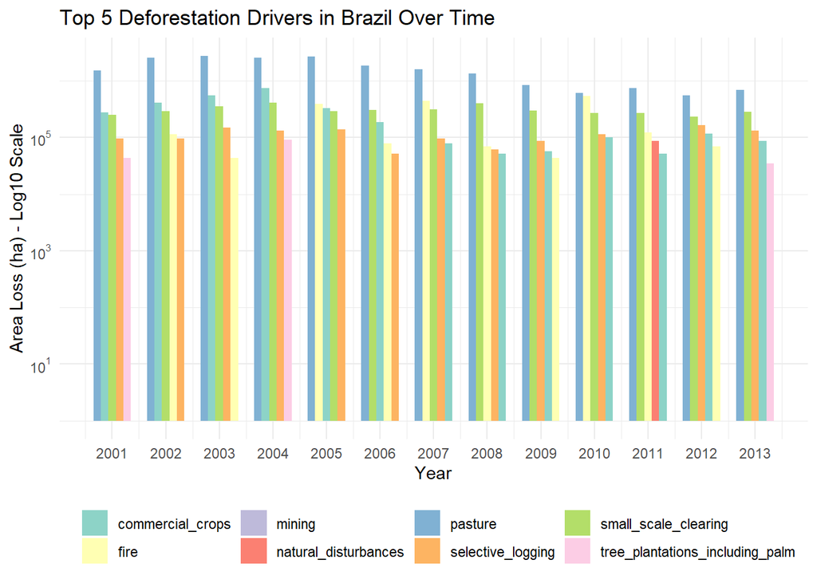

```r
brazil_long_top5 <- brazil_loss %>%
  select(-entity, -code) %>%
  pivot_longer(cols = -year,
               names_to = "driver",
               values_to = "value") %>%
  filter(value != 0) %>%
  group_by(year) %>%
  top_n(5, value) %>%
  ungroup() %>%
  mutate(rank = dense_rank(-value)) %>% # Add this line to compute rank within each year
  arrange(year, rank) # Change this line to sort by year and rank

ggplot(brazil_long_top5, aes(x = year, y = value, fill = driver, group = rank)) + # Add group aesthetic
  geom_col(position = "dodge", width = 0.7) +
  labs(title = "Top 5 Deforestation Drivers in Brazil Over Time",
       x = "Year",
       y = "Area Loss (ha) - Log10 Scale",
       fill = "Driver") +
  theme_minimal() +
  scale_fill_brewer(palette = "Set3") +
  theme(legend.position = "bottom",
        legend.title = element_blank(),
        panel.spacing = unit(0.5, "cm")) +
  scale_y_log10(labels = scales::trans_format("log10", scales::math_format(10^.x))) +
  scale_x_continuous(breaks = unique(brazil_long_top5$year))
```

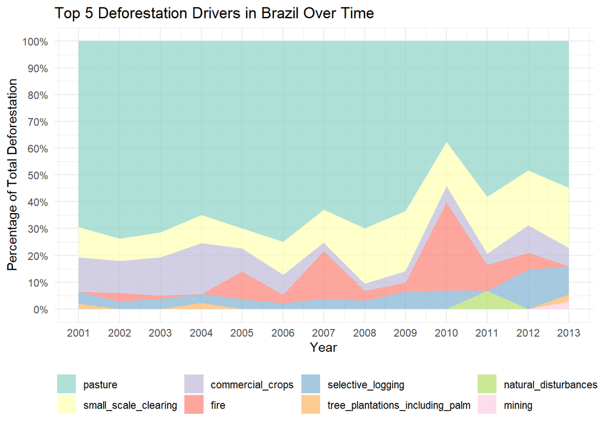

```r
brazil_long_top5 <- brazil_loss %>%
  select(-entity, -code) %>%
  pivot_longer(cols = -year,
               names_to = "driver",
               values_to = "value") %>%
  group_by(year) %>%
  top_n(5, value) %>%
  ungroup()

# Create a complete dataset with all combinations of years and drivers
complete_data <- expand.grid(year = unique(brazil_long_top5$year),
                             driver = unique(brazil_long_top5$driver))

# Merge the complete dataset with brazil_long_top5 and replace any missing values with 0
brazil_long_top5_filled <- merge(complete_data, brazil_long_top5, by = c("year", "driver"), all.x = TRUE) %>%
  replace_na(list(value = 0))

# Calculate the total deforestation per year and the percentage for each driver
brazil_long_top5_filled <- brazil_long_top5_filled %>%
  group_by(year) %>%
  mutate(total_deforestation = sum(value),
         percentage = value / total_deforestation) %>%
  ungroup()

# Reorder the driver factor levels based on the total deforestation caused by each driver
total_deforestation_by_driver <- brazil_long_top5_filled %>%
  group_by(driver) %>%
  summarise(total_deforestation = sum(value)) %>%
  arrange(-total_deforestation)

brazil_long_top5_filled$driver <- factor(brazil_long_top5_filled$driver,
                                         levels = total_deforestation_by_driver$driver)

# Create the stacked area chart with the y-axis as a percentage
ggplot(brazil_long_top5_filled, aes(x = year, y = percentage, fill = driver)) +
  geom_area(position = "stack", alpha = 0.7) +
  labs(title = "Top 5 Deforestation Drivers in Brazil Over Time",
       x = "Year",
       y = "Percentage of Total Deforestation",
       fill = "Driver") +
  theme_minimal() +
  scale_fill_brewer(palette = "Set3") +
  theme(legend.position = "bottom",
        legend.title = element_blank(),
        panel.spacing = unit(0.5, "cm")) +
  scale_y_continuous(labels = scales::percent, breaks = seq(0, 1, 0.1)) +
  scale_x_continuous(breaks = unique(brazil_long_top5_filled$year))
```

### Discussions

The visualizations help readers understand the top 5 drivers of deforestation in Brazil and their evolution over time. The dodged bar chart shows the magnitude of area loss for each driver yearly, while the stacked area chart highlights their relative contributions to total deforestation.Trends reveal that the main drivers have fluctuated over the years, with some consistently maintaining high contributions and others changing in significance. The stacked area chart allows observation of any dominant driver or changes in leading causes of deforestation. The factors affecting deforestation in Brazil are agricultural practices, urbanization, logging activities, and policy implementations. By analyzing these visualizations, we can better understand which factors are most important and make well-informed decisions to address deforestation effectively.

## Reference

[1]“How China brought its forests back to life in a decade,” Rapid Transition Alliance, 02-Dec-2018. [Online]. Available: https://www.rapidtransition.org/stories/how-china-brought-its-forests-back-to-life-in-a-decade/.

[2]R. A. Butler, “Congo deforestation,” Mongabay, 09-Feb-2020. [Online]. Available: https://rainforests.mongabay.com/congo/deforestation.html.

https://raw.githubusercontent.com/rfordatascience/tidytuesday/master/data/2021/2021-04-06/forest_area.csv’

https://raw.githubusercontent.com/rfordatascience/tidytuesday/master/data/2021/2021-04-06/brazil_loss.csv’